# Lab Module: Interactive Plots & Tables

PHW251B: Data Visualization for Public Health

## Introduction

Welcome back to PHW251B! This lab module will be covering various interactive plots and tables that can be created in R with different packages. We will be extending various types of plots that we have been working with thus far in ways that allow for increased engagement and flexibility for our audiences. Interactive plots are incredibly powerful in R, since the reproducibility can allow for on-the-fly dashboards and interactive reports that need minimal upkeep after the initial coding. Creating interactive plots also encompasses the ideals of accessibility needed for static visualizations, and requires additional care when considering the user interactivity and experience. We will try to keep this in mind while exploring options in packages such as `plotly`, `datatables` and others.

## Objectives

- Explore `plotly` and how to create interactive plots from existing `ggplot2` objects
- Create native `plotly` objects
- Explore other interactive graphing libraries like `ggiraph`
- Create interactive tables with `DT` and `reactable`

## The Data

Today we’ll be using a variety of datasets.

**US EPA Air Quality Index, Historical Data**

AQI, or Air Quality Index, is the primary way to measure the current quality of the air.

AQI values are given these ranges:

| AQI Ranges | Category | Colors |
| --- | --- | --- |
| 0-50 | Good | Green |
| 51-100 | Moderate | Yellow |
| 101-150 | Unhealthy for Sensitive Groups | Orange |
| 151-200 | Unhealthy | Red |
| 201-300 | Very Unhealthy | Purple |
| 301-500 | Hazardous | Maroon |

This dataset includes observations for individual air monitoring areas across the *entire* United States and their daily air pollution measurements dating from 1980 to present day. An area is made up of a series of air pollution monitors within it. Each observation also includes the latitude and longitude of the air monitoring area and residential population from where it was taken.

Here are the individual variables and their descriptions:

- CBSA Code: The core-based statistical area (CBSA) code. CBSA = a U.S. geographic area defined by the Office of Management and Budget (OMB) that consists of one or more counties.
- Date: The day of measurement.
- AQI: The average air quality index (AQI) value for the day.
- Category: The category of air quality ranging from “Good” to “Hazardous”.
- Defining Parameter: One of PM2.5 (particulate matter), PM10, Ozone, Carbon Monoxide, Sulfur Dioxide, or Nitrogen Dioxide which has the highest concentration.
- Number of Sites Reporting: The number of stations used to make the data aggregation.
- city_ascii: Name of the city where the measurement was taken.
- state_id: Abbreviation of the state where the measurement was taken.
- state_name: The state where the measurement was taken.
- lat: The latitude where the measurement was taken.
- lng: The longitude where the measurement was taken.
- population: The population of the region where the measurement was taken.
- density: The population per square kilometer where the measurement was taken.
- timezone: The time zone of the region where the measurement was taken.

These data are provided by the US EPA through their EPA Data Mart. For more information, check here: https://aqs.epa.gov/aqsweb/airdata/download_files.html

## Related Resources

- `Plotly` for R: https://plotly.com/r/
- Interactive web-based data visualization with R, `plotly`, and `shiny`: https://plotly-r.com/index.html
- `DT`, and `R` interface to the `DataTables` library: https://rstudio.github.io/DT/
- The `ggiraph` book: https://www.ardata.fr/ggiraph-book/
- `reactable` for R: https://glin.github.io/reactable/

**Let’s get started!**

Like always, we start with importing the dataset and performing some data cleaning. Then, we’ll perform some exploratory data analysis using static plots and their interactive counterparts. At every part we’ll include annotation explaining the steps taken.

Throughout this module, you will want to **Knit to HTML**, which stands for *HyperText Markup Language* – this is the programming language that undergirds much of the world wide web! It’s a flexible structure that lets different static and dynamic objects interact on one webpage. A fantastic thing about R is that we can create these HTML webpages from a RMarkdown and either present information in an interactive format (as opposed to a static PDF) or even publish directly to the web!

```r
#load rdata file with raw data
load(file = "us_aqi_historical.rdata")

#modify dataset with steps below and assigning to a dataset named ca_aqi
ca_aqi <- us_aqi_historical %>%
  #rename columns to lowercase and replacing spaces with underscores
  rename_with(~ tolower(gsub(" ","_", .x, fixed=TRUE))) %>%
  #filter for CA in the state_id column
  filter(state_id == "CA")

#take a peek!
head(ca_aqi)
```

| ...1 | cbsa_code | date | aqi | category | defining_parameter | number_of_sites_reporting | city_ascii | state_id | state_name | lat | lng | population | density | timezone |
| --- | --- | --- | --- | --- | --- | --- | --- | --- | --- | --- | --- | --- | --- | --- |
| 1325 | 12540 | 2022-01-01 | 69 | Moderate | PM2.5 | 2 | Bakersfield | CA | California | 35.3529 | -119.0359 | 556892 | 979 | America/Los_Angeles |
| 1326 | 12540 | 2022-01-02 | 137 | Unhealthy for Sensitive Groups | PM2.5 | 3 | Bakersfield | CA | California | 35.3529 | -119.0359 | 556892 | 979 | America/Los_Angeles |
| 1327 | 12540 | 2022-01-03 | 58 | Moderate | PM2.5 | 2 | Bakersfield | CA | California | 35.3529 | -119.0359 | 556892 | 979 | America/Los_Angeles |
| 1328 | 12540 | 2022-01-04 | 56 | Moderate | PM2.5 | 2 | Bakersfield | CA | California | 35.3529 | -119.0359 | 556892 | 979 | America/Los_Angeles |
| 1329 | 12540 | 2022-01-05 | 127 | Unhealthy for Sensitive Groups | PM2.5 | 3 | Bakersfield | CA | California | 35.3529 | -119.0359 | 556892 | 979 | America/Los_Angeles |
| 1330 | 12540 | 2022-01-06 | 71 | Moderate | PM2.5 | 2 | Bakersfield | CA | California | 35.3529 | -119.0359 | 556892 | 979 | America/Los_Angeles |

### AQI Categories

We have a variable named `category` that describes designations of specific air quality ranges that are determined to be generally safe, unsafe, or dangerous for the public by the EPA. Given that this a categorical variable, we can already think back to our material that covers plots for such data – namely, **bar charts**! Let’s explore the data and make some visualizations.

```r
#how many specific AQI categories in our dataset?
length(unique(ca_aqi$category))
```

```
## [1] 6
```

```r
#what are the specific AQI categories in our dataset?
unique(ca_aqi$category)
```

```
## [1] "Moderate"                       "Unhealthy for Sensitive Groups"
## [3] "Unhealthy"                      "Good"
## [5] "Very Unhealthy"                 "Hazardous"
```

```r
#how many times do each of these occur in the dataset?
table(ca_aqi$category)
```

```
##
##                           Good                      Hazardous
##                         264708                            344
##                       Moderate                      Unhealthy
##                         139753                          19710
## Unhealthy for Sensitive Groups                 Very Unhealthy
##                          45444                           7861
```

```r
#what if we wanted to turn these into percentages of the dataset?
table(ca_aqi$category) %>% prop.table() %>% round(4)*100
```

```
##
##                           Good                      Hazardous
##                          55.40                           0.07
##                       Moderate                      Unhealthy
##                          29.25                           4.12
## Unhealthy for Sensitive Groups                 Very Unhealthy
##                           9.51                           1.65
```

```r
#factor variables so the order makes sense
ca_aqi$category <- factor(ca_aqi$category,
                          levels = c("Good", "Moderate",
                                     "Unhealthy for Sensitive Groups",
                                     "Unhealthy", "Very Unhealthy", "Hazardous"),
                          ordered = T)
```

After doing the above exploration of the `category` variable, we can make a grouped-by dataset to visualize the data using a bar chart, drawing from previous modules for summary statistics and bar charts.

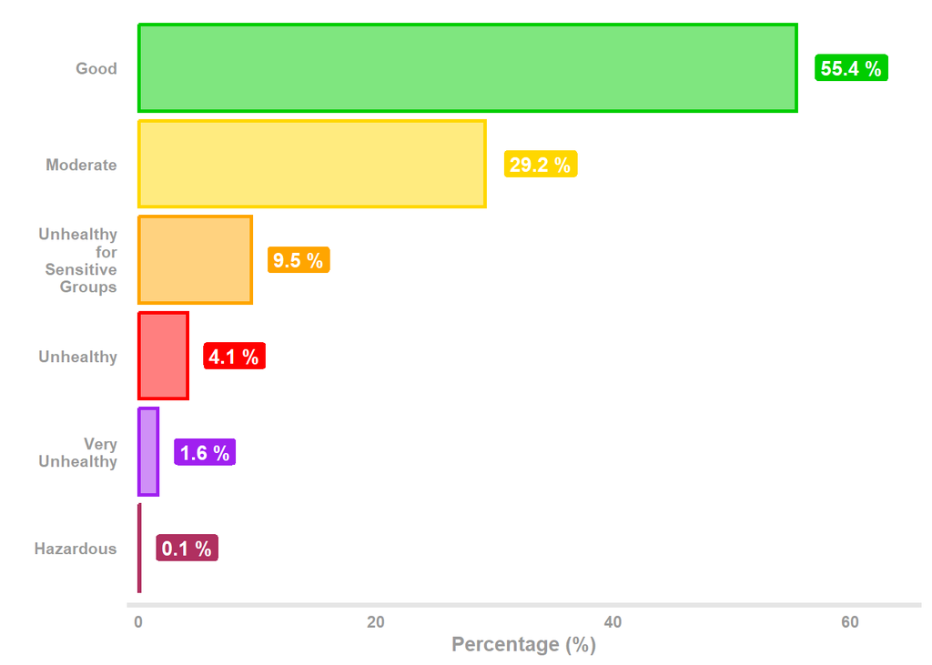

```r
#let's see how much of the total dataset lies in each category!
aqi_categories_percentage <- ca_aqi %>%
  #group by category of AQI
  group_by(category) %>%
  #number of observations in a unique group divided by the number of rows in the dataset
  summarise(percentage = 100*n()/nrow(ca_aqi)) %>%
  #round numeric columns to one digit
  mutate_if(is.numeric, round, 1)

#let's make a static ggplot object for this, store to object called bar_static!
bar_static <- ggplot(data = aqi_categories_percentage, aes(y = category,
                                                           x = percentage,
                                                           fill = category)) +
  #geom col, encode by category, border of linewidth 1, fill of alpha/transparency 0.5
  geom_col(aes(color = category), linewidth = 1, alpha = 0.5) +
  #add data labels of percentage + %, text color is white, adjust horizontal position, bolded
  geom_label(aes(label = paste(percentage, "%")), color = "white", hjust = -0.25, fontface = "bold") +
  #reverse direction of y-axis categories, add text wrap to labels (multiline)
  scale_y_discrete(limits = rev(levels(aqi_categories_percentage$category)),
                   labels = label_wrap(10)) +
  #add manual fill and color scales to match color categories given for AQI
  scale_fill_manual(values = c("green3", "gold", "orange", "red", "purple", "maroon")) +
  scale_color_manual(values = c("green3", "gold", "orange", "red", "purple", "maroon")) +
  #adjust x axis start point
  scale_x_continuous(expand = c(0,1), limits = c(0, 65)) +
  #add white background
  theme(panel.background = element_rect(fill = "white"),
        #take out grid
        panel.grid = element_blank(),
        #take out ticks
        axis.ticks = element_blank(),
        #add custom x axis line
        axis.line.x = element_line(color = "grey90", linewidth = 1.25),
        #bold axis titles, make a medium-darkness gray
        axis.title = element_text(color = "grey60", face = "bold"),
        #bold axis text (categories), make medium grey
        axis.text = element_text(color = "grey60", face = "bold")) +
  #remove legends for fill and color
  guides(fill = "none",
         color = "none") +
  #remove y axis title, add x axis title
  labs(y = "",
       x = "Percentage (%)")

#display the ggplot object we just made
bar_static
```

Now that we’ve made this aggregated dataset and `ggplot` object with different methods that we know and love, let’s convert it to an interactive `plotly` object. The process is extremely straightforward – we drop our `ggplot` object into `ggplotly()`, a function that converts it to a `plotly` object.

```r
#convert this into a plotly object using `ggplotly()` wrapped around the ggplot2 object -- it's that easy!

#make the same ggplot object as above, just adding the `text` object in aes() to use in the interactive hover text
bar_static <- ggplot(data = aqi_categories_percentage, aes(y = category,
                                                           x = percentage,
                                                           fill = category,
                                                           #the hover text will read "Percentage: ##%"
                                                           text = paste("Percentage:", percentage))) +
  #geom col, encode by category, border of size 1, fill of alpha/transparency 0.5
  geom_col(aes(color = category), size = 1, alpha = 0.5) +
  #add data labels of percentage + %, text color is white, adjust horizontal position, bolded
  geom_label(aes(label = paste(percentage, "%")), color = "white", hjust = -0.25, fontface = "bold") +
  #reverse direction of y-axis categories, add text wrap to labels (multiline)
  scale_y_discrete(limits = rev(levels(aqi_categories_percentage$category)),
                   labels = label_wrap(10)) +
  #add manual fill and color scales to match color categories given for AQI
  scale_fill_manual(values = c("green3", "gold", "orange", "red", "purple", "maroon")) +
  scale_color_manual(values = c("green3", "gold", "orange", "red", "purple", "maroon")) +
  #adjust x axis start point
  scale_x_continuous(expand = c(0,1), limits = c(0, 65)) +
  #add white background
  theme(panel.background = element_rect(fill = "white"),
        #take out grid
        panel.grid = element_blank(),
        #take out ticks
        axis.ticks = element_blank(),
        #add custom x axis line
        axis.line.x = element_line(color = "grey90", size = 1.25),
        #bold axis titles, make a medium-darkness gray
        axis.title = element_text(color = "grey60", face = "bold"),
        #bold axis text (categories), make medium grey
        axis.text = element_text(color = "grey60", face = "bold")) +
  #remove legends for fill and color
  guides(fill = "none",
         color = "none") +
  #remove y axis title, add x axis title
  labs(y = "",
       x = "Percentage (%)")
#referencing the text object in the ggplotly call
ggplotly(bar_static, tooltip = "text") %>%
  #remove legend through a plotly function, ggplotly doesn't translate guides correctly
  layout(showlegend = FALSE)
```

[interactive chart not shown]

You’ll notice there’s a few issues, though – there’s a ton of error messages that suggest that `plotly` doesn’t understand a lot of these additional modifications. For example, the `geom_label()` doesn’t appear.

If you remove the `toolip = "text"` argument from the `ggplotly` function, you’ll see that when hovering over specific bars, we see that the `category` field is repeated. Interestingly, the hover text is comprised of any variables that we put in an `aes()` argument! That’s why we see `category` three times. This is an easy and quick solution to make our plots interactive, but there are some quirks that we must be aware of. We may have more granular control by making native `plotly` objects.

### plotly vs. ggplotly

This may be a point of confusion, but there’s actually two ways we’re approaching interactive plots here, with some subtle distinctions!

Before this module, we have been using `ggplot` to create static graphs, plots, and maps! It has its own syntax, or “grammar” to build plots (`ggplot() + geom()`, what you’ve been familiar with). `ggplot` is made just for static plots, or ones that are not interactive. They’re great for printed PDFs and HTML reports that don’t need interactivity.

`plotly` is a library that is built on Javascript and has its own syntax, or grammar (which we’ll cover more below) that is separate from `ggplot`. When we say “native plotly object”, it means to create a plotly visualization with its grammar, or syntax. It’s primary purpose is to build interactive plots, where observations on the graph/chart/plot can be selected and/or investigated further. Normally, these are presented in HTML reports/dashboards. You can still knit them to static PDFs, but they will be static and *sometimes may not show up at all*.

**So what’s ggplotly()?**

`ggplotly` is a package that takes a static `ggplot` object and converts it into a `plotly` object! Meaning, you can create a plot using the normal `ggplot` grammar and syntax that you know, but transform it into an interactive plot. It’s really neat, and sometimes offers more customization flexibility than building a native `plotly` object – some examples to follow. Going forward, the “ggplotly method” refers to first creating a `ggplot` object and then passing it through `ggplotly` to make it interactive!

## Plotly Structure

The general `plotly` structure is fairly straightforward, and is similar to `ggplot2` in many ways:

`plot_ly(data = dataframe, x = var1, y = var2, type = "bar", color = "", alpha = "", size = "", ... )`

Take a look here for more native `plotly` code structure: https://plotly.com/r/reference/index/

```r
#pull up documentation for plotly
?plot_ly
```

```
## starting httpd help server ... done
```

```r
#note how plotly uses the %>% instead of + that ggplot uses to stack functions on top of each other!
#basic horizontal bar chart
plot_ly() %>%
  add_trace(data = aqi_categories_percentage,
            #specify x axis
            x = ~percentage,
            #specify y axis
            y = ~category,
            #specify type of chart
            type = "bar") %>%
  layout(title = "Basic Plotly Horizontal Bar Chart")
```

[interactive chart not shown]

```r
#plotly object with more modifications to be in line with the ggplot object we made earlier

#initialize plotly (like making an empty ggplot item)
plot_ly() %>%
  #add trace is akin to adding a geom_object
  add_trace(data = aqi_categories_percentage,
            #specify x axis
            x = ~percentage,
            #specify y axis
            y = ~category,
            #specify type of chart
            type = "bar",
            #indicate data labels and position of said labels
            text = ~percentage, textposition = "outside",
            #create manual discrete color scale for filled bars, emulating viridis palette, alpha = 0.5 (half transparency)
            marker = list(color = c("rgba(50, 205, 50, 0.5)",
                                    "rgba(255, 200, 0, 0.5)",
                                    "rgba(255, 165, 0, 0.5)",
                                    "rgba(255, 0, 0, 0.5)",
                                    "rgba(138, 43, 226, 0.5)",
                                    "rgba(178, 34, 34, 0.5)"),
                          #manual discrete color scale for border, viridis palette, alpha = 1.0
                          line = list(color = c("rgba(50, 205, 50, 1.0)",
                                    "rgba(255, 200, 0, 1.0)",
                                    "rgba(255, 165, 0, 1.0)",
                                    "rgba(255, 0, 0, 1.0)",
                                    "rgba(138, 43, 226, 1.0)",
                                    "rgba(178, 34, 34, 1.0)"),
                                    #width of border = 2
                                    width = 2))) %>%
  #order the categories (it should be descending, but plotly reads the factors in reverse)
  layout(yaxis = list(title = "", categoryorder = "total ascending"),
         #add xaxis title
         xaxis = list(title = "Percentage (%)"),
         title = "Plotly duplicate of ggplot chart")
```

[interactive chart not shown]

Plotly isn’t without its own limitations and quirks – above is an example of my attempt to replicate the original ggplot object, but with some caveats (some of which are the limitations of my own documentation-searching and implementation skills):

- No direct replacement for `geom_text`
- Missing line breaks in the y-axis labels (if anyone can figure this out, I’d love to learn how!)
- Translucent fill but opaque borders without explicit coding

Which is the better implementation? That’s really up to your discretion! In this bar charts example, there’s a few decisions to make about legibility and customization, and my personal preference would be the `ggplotly` implementation. In my experience, `plotly` charts end up looking quite similar to each other since the range of visual changes is limited compared to `ggplot`. However, if the interactivity is your main priority, it may not matter.

Where `plotly` stumbles especially is the consistency and availability of documentation. Despite `plotly` being a major cross-language library (it’s widely used in `Python`), the `R`-verse doesn’t have great documentation and expansion (yet!), and it can leave people who want more granular control over aesthetics wanting. This is where `ggplotly` can fill the gap.

## Continuous Data

Next, we’ll move onto some univariate and multivariate plots with `plotly` and their `ggplot` counterparts.

Let’s look at the distribution of AQI values within this dataset, first with some summarizing functions and then with plots. Note that AQI is measured in integers (whole numbers), so it might not lend to the smoothest univariate plots.

Some takeaways:

- `aqi` has a right skew distribution (we can see this with the mean being higher than median) with several very large outliers
- 0.04% of the dataset has an AQI above 500, or what is considered “extremely hazardous”

### Density & Univariate Distribution

```r
#see a continuous summary of the variable -- we see that it is right skewed with a huge outlier
summary(ca_aqi$aqi)
```

```
##     Min.  1st Qu.   Median     Mean  3rd Qu.     Max.
##     0.00    37.00    47.00    63.82    77.00 20646.00
```

```r
#how many outliers do we see above 500 AQI (what is considered "extremely hazardous")?
nrow(ca_aqi %>% filter(aqi > 500))/nrow(ca_aqi)*100
```

```
## [1] 0.0439496
```

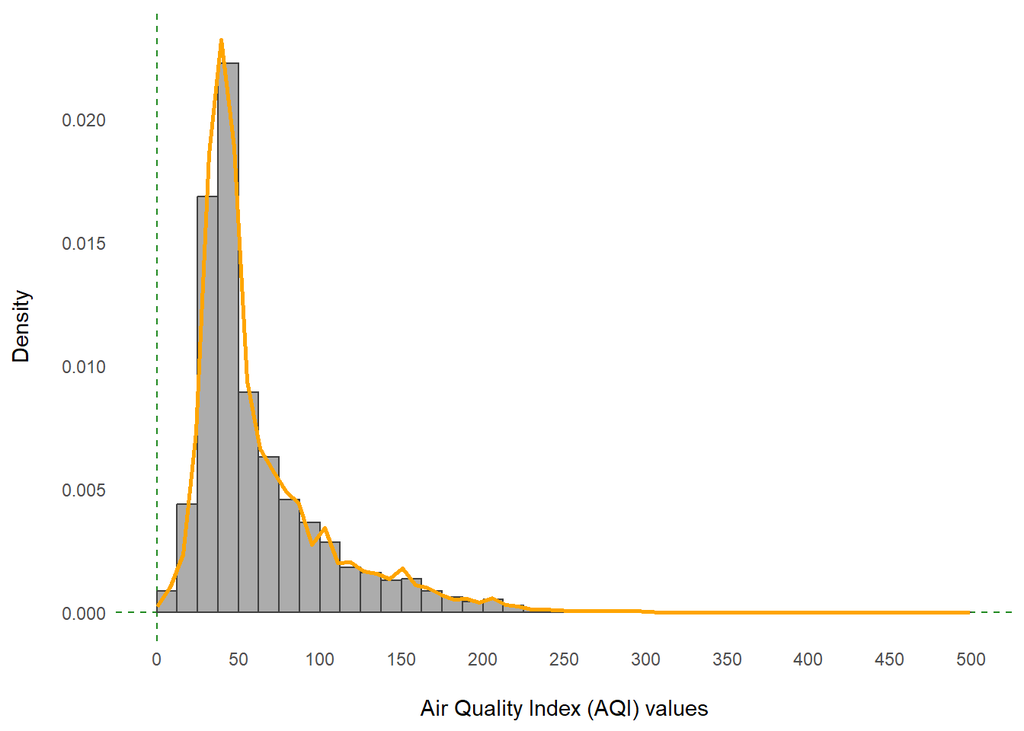

```r
#let's subset our data to values below 500
aqi_histogram <- ggplot(data = ca_aqi %>% filter(aqi < 500), aes(x = aqi)) +
  #add horizontal reference line at y = 0, in a dashed forest green
  geom_hline(yintercept = 0, color = "forestgreen", linetype = "dashed") +
  #add vertical reference line at x = 0, in dashed forest green
  geom_vline(xintercept = 0, color = "forestgreen", linetype = "dashed") +
  #add histogram, specifying density instead of count, half transparency and binwidth of 12.5 starting at x = 0
  geom_histogram(aes(y = ..density..),
                 alpha = 0.5,
                 color = "grey25",
                 binwidth = 12.5,
                 boundary = 0) +
  #add density line in orange with a gaussian kernel density smoothing factor of 2^6
  geom_density(color = "orange", n = 2^6, size = 1.0, kernel = "gaussian")+
  #add custom breaks on x axis
  scale_x_continuous(breaks = seq(0, 500, 50)) +
  theme_minimal() +
  #remove grids in panel
  theme(panel.grid = element_blank()) +
  labs(y = "Density\n",
       x = "\nAir Quality Index (AQI) values")

aqi_histogram
```

```r
#let's look at an untouched ggplotly conversion
ggplotly(aqi_histogram)
```

[interactive chart not shown]

In this case, the `ggplotly` conversion works wonderfully! I have little critique of it, except for the hover tooltip, which can be additionally customized, and the repeated orange density line at the horizontal intercept. It’s a great example of why `ggplotly` can really streamline a workflow! In this case, I would likely remove the density curve, as it doesn’t seem to add much information that we would be missing. For kicks, let’s try to make a native `plotly` rendition:

```r
#without modifications, base plotly plot
plot_ly(data = ca_aqi %>% filter(aqi < 500), x = ~aqi, type = "histogram")
```

[interactive chart not shown]

Note the very fine density – the binwidth is really small, it might even be a width of 1 (turns out – it is). If you hover your mouse over individual bars it’ll return an individual AQI value. Neat!). Let’s add a few more modifications to better match our original `ggplot` object, some of which can be found here: https://plotly.com/r/histograms/

```r
#create functions for reference lines
hline <- function(y = 0, color = "forestgreen") {
  list(
    type = "line",
    #x extents of the reference line
    x0 = 0,
    x1 = 1,
    xref = "paper",
    #y extents will be determined by the input y = #
    y0 = y,
    y1 = y,
    line = list(color = color, dash = "dot")
  )
}

vline <- function(x = 0, color = "forestgreen") {
  list(
    type = "line",
    #x extents determined by input x = #
    x0 = x,
    x1 = x,
    xref = "paper",
    y0 = 0,
    #note that I set the y boundary here
    y1 = 0.4,
    line = list(color = color, dash = "dot")
  )
}

plot_ly(data = ca_aqi %>% filter(aqi < 500), x = ~aqi, type = "histogram",
        #change histogram to density function rather than counts, specify 40 bins in the entire range
        histnorm = "probability", nbinsx = 40,
        marker = list(color = "#adb5bd", line = list(color = "343a40", width = 2))) %>%
  layout(shapes = list(hline(0), vline(0)), xaxis = list(title = "Air Quality Index (AQI) values"), yaxis = list(title = "Density\n"))
```

[interactive chart not shown]

Since `plotly` begins plots at the origin (0,0) and doesn’t “float” in space like `ggplot` does, the reference lines don’t add much, in my opinion. Also, I couldn’t find a way to programatically add a density plot to the `plotly` object (if anyone figures it out, please give a shout!), so in this use-case scenario, I recommend the `ggplotly` method.

Let’s move onto some bivariate plots! First, we’ll use some of the geographic information systems tools we used in Week 9 to add information to our dataset: namely, what county the observations reside in.

```r
#use the tigris library again to pull county shapefiles
counties <- tigris::counties(state = "California", progress_bar = FALSE) %>%
  rename_with(~ tolower(gsub(" ","_", .x, fixed=TRUE)))
#convert the ca_aqi dataset into an sf object, setting crs = 4269 (same as counties)
ca_aqi_geo <- st_as_sf(ca_aqi, coords = c("lng", "lat"), crs = 4269)

#here, we'll indicate that we want to keep the geometry of ca_aqi (points, indicated by the lat/long) but we do want to know which counties it is within (y = counties)
ca_aqi_geo <- sf::st_join(x = ca_aqi_geo, y = counties %>% rename("county" = "name") %>% select(county, geometry), left = TRUE)

#you'll note that in the geometry field it stays as a sfc_POINT, instead of MULTIPOLYGON, and we have one more column called "county"
head(ca_aqi_geo)
```

| ...1 | cbsa_code | date | aqi | category | defining_parameter | number_of_sites_reporting | city_ascii | state_id | state_name | population | density | timezone | geometry | county |
| --- | --- | --- | --- | --- | --- | --- | --- | --- | --- | --- | --- | --- | --- | --- |
| 1325 | 12540 | 2022-01-01 | 69 | Moderate | PM2.5 | 2 | Bakersfield | CA | California | 556892 | 979 | America/Los_Angeles |  | Kern |
| 1326 | 12540 | 2022-01-02 | 137 | Unhealthy for Sensitive Groups | PM2.5 | 3 | Bakersfield | CA | California | 556892 | 979 | America/Los_Angeles |  | Kern |
| 1327 | 12540 | 2022-01-03 | 58 | Moderate | PM2.5 | 2 | Bakersfield | CA | California | 556892 | 979 | America/Los_Angeles |  | Kern |
| 1328 | 12540 | 2022-01-04 | 56 | Moderate | PM2.5 | 2 | Bakersfield | CA | California | 556892 | 979 | America/Los_Angeles |  | Kern |
| 1329 | 12540 | 2022-01-05 | 127 | Unhealthy for Sensitive Groups | PM2.5 | 3 | Bakersfield | CA | California | 556892 | 979 | America/Los_Angeles |  | Kern |
| 1330 | 12540 | 2022-01-06 | 71 | Moderate | PM2.5 | 2 | Bakersfield | CA | California | 556892 | 979 | America/Los_Angeles |  | Kern |